# deMULTIplexing our data: addressing barcode IDs to cells

#Install deMULTIplex and dependencies: Info at https://github.com/chris-mcginnis-ucsf/MULTI-seq

Loading libraries and setting WD #setup

```r
library('ShortRead')
library('deMULTIplex')
library('KernSmooth')
library('reshape2')
library('Rtsne')
library('stringdist')
library("knitr")
library("dplyr")
setwd("/data4/svz_10x/wholecell/data/fastq/subsampled/Originals")
```

```
The working directory was changed to /data4/svz_10x/wholecell/data/fastq/subsampled/Originals inside a notebook chunk. The working directory will be reset when the chunk is finished running. Use the knitr root.dir option in the setup chunk to change the working directory for notebook chunks.
```

#Define vectors for reference barcode sequences and cell IDs

```r
load("/data4/marcos/WC - Mouse 2020/WC_sctransformed_20200103.RData")

#Barcodes used: A3(TGAGACCT), A4(GCACACGC), A5(AGAGAGAG), A6 (TCACAGCA)
cell.id.vec <- names(experiment$orig.ident)
multi.ref <- c("TGAGACCT", "GCACACGC", "AGAGAGAG", "TCACAGCA")
```

#Subsampling Loading the original FastQ files was not possible due their huge size (R2 is 27gb, while the preprocessing is optimized for files under 2gb). We have to downsample our barcode fastqfiles to 100M reads:

David Wu suggested a simpler and faster alternative:

k = 100000000 seqtk sample TGACCAAT_S5_L001_R2_001.fastq $100000000 > TGACCAAT_S5_L001_R2_001_subsampled.fastq gzip TGACCAAT_S5_L001_R1_001_subsampled.fastq —- David’s suggestion didn’t work, checked seqtk documentation and used the following code:

gunzip TGACCAAT_S5_L001_R2_001.fastq.gz gunzip TGACCAAT_S5_L001_R1_001.fastq.gz seqtk sample -s100 TGACCAAT_S5_L001_R2_001.fastq 100000000 > TGACCAAT_S5_L001_R2_001_subsampled.fastq seqtk sample -s100 TGACCAAT_S5_L001_R1_001.fastq 100000000 > TGACCAAT_S5_L001_R1_001_subsampled.fastq gzip TGACCAAT_S5_L001_R2_001_subsampled.fastq gzip TGACCAAT_S5_L001_R1_001_subsampled.fastq

gunzip ACAGTGAT_S6_L001_R1_001.fastq.gz gunzip ACAGTGAT_S6_L001_R2_001.fastq.gz seqtk sample -s100 ACAGTGAT_S6_L001_R1_001.fastq 100000000 > ACAGTGAT_S6_L001_R1_001_subsampled.fastq seqtk sample -s100 ACAGTGAT_S6_L001_R2_001.fastq 100000000 > ACAGTGAT_S6_L001_R2_001_subsampled.fastq gzip ACAGTGAT_S6_L001_R2_001_subsampled.fastq gzip ACAGTGAT_S6_L001_R1_001_subsampled.fastq

#Loading FastQ files

```r
#tgacaat - B1
#acagtgat - B2

#B1:
readTable.b1 <- MULTIseq.preProcess(R1 = "/data4/svz_10x/wholecell/data/fastq/subsampled/TGACCAAT_S5_L001_R1_001_subsampled.fastq.gz", R2 = "/data4/svz_10x/wholecell/data/fastq/subsampled/TGACCAAT_S5_L001_R2_001_subsampled.fastq.gz", cellIDs = cell.id.vec)
```

```
[1] "Reading in R1..."
```

## this was my first attempt at running the pipeline with a merged dataset. Doesn’t work properly due to index hopping. I am leaving this chunk here for now because it has the commands I ran to determine B1 and B2 cells IDs.

```r
readTable <- bind_rows(readTable.b1, readTable.b2)
save(readTable, file="readTable.full.Rdata")
```

#Checking the number of unique cells

[output not shown]

[output cut: 990 more lines]

```r
unique(readTable.b1 %>% select(Cell)) #30,928

unique(readTable.b2 %>% select(Cell)) #33,319
```

|  | Cell |
| --- | --- |
| 2 | TATCTTGCACCGGTCA |
| 3 | TCAAGTGGTTCAAACC |
| 4 | GTGCTGGGTCCACTTC |
| 6 | GTTACAGAGATAGTCA |
| 8 | GCAACCGAGTGAATAC |
| 10 | GCAGCTGTCCTACCGT |
| 11 | TTCCGGTTCTTTGGAG |
| 12 | GCCGATGTCACCCTTG |
| 13 | ACGATCACAATACCCA |
| 14 | TGACCCTAGTGTAGTA |

[output cut: 990 more lines]

```r
unique(readTable %>% select(Cell)) #33,370
```

|  | Cell |
| --- | --- |
| 1 | ATTCCTACATACTGAC |
| 2 | GTAGAGGCAGGCAATG |
| 3 | GGGACAATCGTGTCAA |
| 4 | CCTCATGTCGGTGTTA |
| 5 | ATAGAGATCTCCCAAC |
| 6 | TGAACGTAGGATATAC |
| 7 | TATTGCTGTCATAACC |
| 8 | GTGTTAGGTCTAGATC |
| 9 | AGTGACTTCCATGATG |
| 10 | GTAGGTTAGTTTCGGT |

[output cut: 990 more lines]

## Perform MULTI-seq sample barcode alignment

```r
bar.table.b2 <- MULTIseq.align(readTable.b2, b2.cells.fixed, multi.ref)
```

```
[1] "Bucketing cell IDs..."
[1] "Bucketing read tables..."
[1] "Aligning bucket #1..."
[1] "2020-05-01 12:35:17 PDT"
[1] "Done aligning bucket #1..."
Time difference of 1.244043 hours
[1] "Aligning bucket #2..."
[1] "2020-05-01 13:49:55 PDT"
[1] "Done aligning bucket #2..."
Time difference of 34.42499 mins
```

```r
save(bar.table.b2, file = "bar.table.b2.Rdata")
```

#Visual inspection in the barcode space

```r
#B1
bar.tsne.b1 <- barTSNE(bar.table.b1 [,1:4])
```

```
Performing PCA
Read the 18046 x 4 data matrix successfully!
OpenMP is working. 1 threads.
Using no_dims = 2, perplexity = 30.000000, and theta = 0.500000
Computing input similarities...
Building tree...
 - point 10000 of 18046
Done in 6.54 seconds (sparsity = 0.006692)!
Learning embedding...
Iteration 50: error is 104.983073 (50 iterations in 4.56 seconds)
Iteration 100: error is 94.943243 (50 iterations in 4.84 seconds)
Iteration 150: error is 82.644219 (50 iterations in 4.25 seconds)
Iteration 200: error is 79.355326 (50 iterations in 4.15 seconds)
Iteration 250: error is 77.763165 (50 iterations in 4.19 seconds)
Iteration 300: error is 3.136849 (50 iterations in 4.13 seconds)
Iteration 350: error is 2.771443 (50 iterations in 3.95 seconds)
Iteration 400: error is 2.522599 (50 iterations in 4.03 seconds)
Iteration 450: error is 2.340974 (50 iterations in 4.07 seconds)
Iteration 500: error is 2.202368 (50 iterations in 4.07 seconds)
Iteration 550: error is 2.092389 (50 iterations in 4.09 seconds)
Iteration 600: error is 2.002991 (50 iterations in 4.10 seconds)
Iteration 650: error is 1.928560 (50 iterations in 4.13 seconds)
Iteration 700: error is 1.865680 (50 iterations in 4.16 seconds)
Iteration 750: error is 1.811960 (50 iterations in 4.17 seconds)
Iteration 800: error is 1.765678 (50 iterations in 4.18 seconds)
Iteration 850: error is 1.725694 (50 iterations in 4.18 seconds)
Iteration 900: error is 1.690820 (50 iterations in 4.19 seconds)
Iteration 950: error is 1.660506 (50 iterations in 4.20 seconds)
Iteration 1000: error is 1.634283 (50 iterations in 4.82 seconds)
Iteration 1050: error is 1.612224 (50 iterations in 4.27 seconds)
Iteration 1100: error is 1.593830 (50 iterations in 4.24 seconds)
Iteration 1150: error is 1.578080 (50 iterations in 4.24 seconds)
Iteration 1200: error is 1.566809 (50 iterations in 4.27 seconds)
Iteration 1250: error is 1.559374 (50 iterations in 4.29 seconds)
Iteration 1300: error is 1.553394 (50 iterations in 4.32 seconds)
Iteration 1350: error is 1.548044 (50 iterations in 4.33 seconds)
Iteration 1400: error is 1.543508 (50 iterations in 4.31 seconds)
Iteration 1450: error is 1.538427 (50 iterations in 4.27 seconds)
Iteration 1500: error is 1.533772 (50 iterations in 4.26 seconds)
Iteration 1550: error is 1.528848 (50 iterations in 4.24 seconds)
Iteration 1600: error is 1.524332 (50 iterations in 4.23 seconds)
Iteration 1650: error is 1.519699 (50 iterations in 4.23 seconds)
Iteration 1700: error is 1.515327 (50 iterations in 4.23 seconds)
Iteration 1750: error is 1.511223 (50 iterations in 4.23 seconds)
Iteration 1800: error is 1.507117 (50 iterations in 4.23 seconds)
Iteration 1850: error is 1.503106 (50 iterations in 4.22 seconds)
Iteration 1900: error is 1.499483 (50 iterations in 4.58 seconds)
Iteration 1950: error is 1.496105 (50 iterations in 4.20 seconds)
Iteration 2000: error is 1.493130 (50 iterations in 4.21 seconds)
Iteration 2050: error is 1.490079 (50 iterations in 4.20 seconds)
Iteration 2100: error is 1.487456 (50 iterations in 4.20 seconds)
Iteration 2150: error is 1.484809 (50 iterations in 4.20 seconds)
Iteration 2200: error is 1.482295 (50 iterations in 4.21 seconds)
Iteration 2250: error is 1.480307 (50 iterations in 4.18 seconds)
Iteration 2300: error is 1.478381 (50 iterations in 4.18 seconds)
Iteration 2350: error is 1.476139 (50 iterations in 4.18 seconds)
Iteration 2400: error is 1.474039 (50 iterations in 4.18 seconds)
Iteration 2450: error is 1.472149 (50 iterations in 4.18 seconds)
Iteration 2500: error is 1.469960 (50 iterations in 4.19 seconds)
Fitting performed in 211.78 seconds.
```

```r
save(bar.tsne.b1, file="bar.tsne.b1.Rdata")

pdf("b1.bc.check.pdf")
for (i in 3:ncol(bar.tsne.b1)) {
    g <- ggplot(bar.tsne.b1, aes(x = TSNE1, y = TSNE2, color = bar.tsne.b1[,i])) +
    geom_point() +
    scale_color_gradient(low = "black", high = "red") +
    ggtitle(colnames(bar.tsne.b1)[i]) +
    theme(legend.position = "none")
    print(g)
}
dev.off()
```

```r
pdf("b2.bc.check.pdf")
for (i in 3:ncol(bar.tsne.b2)) {
    g <- ggplot(bar.tsne.b2, aes(x = TSNE1, y = TSNE2, color = bar.tsne.b2[,i])) +
    geom_point() +
    scale_color_gradient(low = "black", high = "red") +
    ggtitle(colnames(bar.tsne.b2)[i]) +
    theme(legend.position = "none")
    print(g)
}
dev.off()
```

# Round 1 / B1 —————————————————————————————————–

```r
## Perform Quantile Sweep
bar.table.b1.full <- bar.table.b1[,1:4]
good.bars <- paste("Bar",1:4,sep="")  # Selecting all 4 barcodes
bar.table.b1 <- bar.table.b1.full[, good.bars]  # Remove missing bars and summary columns
bar.table_sweep.list.b1 <- list()
n <- 0
for (q in seq(0.01, 0.99, by=0.02)) {
  print(q)
  n <- n + 1
  bar.table_sweep.list.b1[[n]] <- classifyCells(bar.table.b1, q=q)
  names(bar.table_sweep.list.b1)[n] <- paste("q=",q,sep="")
}
```

```
[1] 0.01
[1] 0.03
[1] 0.05
[1] 0.07
[1] 0.09
[1] 0.11
[1] 0.13
[1] 0.15
[1] 0.17
[1] 0.19
[1] 0.21
[1] 0.23
[1] 0.25
[1] 0.27
[1] 0.29
```

[output cut: 35 more lines]

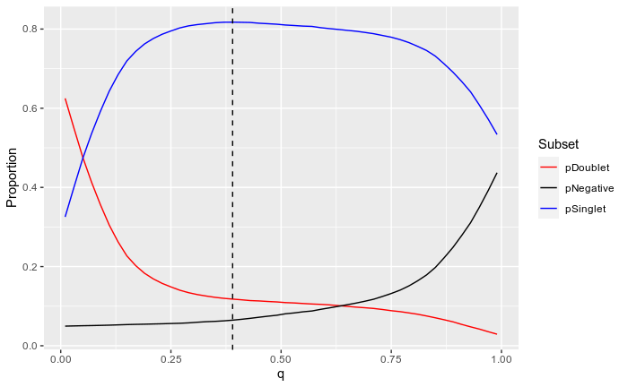

```r
## Identify ideal inter-maxima quantile to set barcode-specific thresholds
threshold.results.b1.1 <- findThresh(call.list=bar.table_sweep.list.b1)
ggplot(data=threshold.results.b1.1$res, aes(x=q, y=Proportion, color=Subset)) + geom_line() +
  geom_vline(xintercept=threshold.results.b1.1$extrema, lty=2) + scale_color_manual(values=c("red","black","blue"))
```

```r
# Finalize round 1 classifications, remove negative cells
b1.round1.calls <- classifyCells(bar.table.b1, q=findQ(threshold.results.b1.1$res, threshold.results.b1.1$extrema))
b1.neg.cells <- names(b1.round1.calls)[which(b1.round1.calls == "Negative")]
bar.table.b1 <- bar.table.b1[-which(rownames(bar.table.b1) %in% b1.neg.cells), ]
```

# Round 1 / B2 —————————————————————————————————–

```r
## Perform Quantile Sweep
bar.table.b2.full <- bar.table.b2[,1:4]
good.bars <- paste("Bar",1:4,sep="")  # Selecting all 4 barcodes
bar.table.b2 <- bar.table.b2.full[, good.bars]  # Remove missing bars and summary columns
bar.table_sweep.list.b2 <- list()
n <- 0
for (q in seq(0.01, 0.99, by=0.02)) {
  print(q)
  n <- n + 1
  bar.table_sweep.list.b2[[n]] <- classifyCells(bar.table.b2, q=q)
  names(bar.table_sweep.list.b2)[n] <- paste("q=",q,sep="")
}
```

```
[1] 0.01
[1] 0.03
[1] 0.05
[1] 0.07
[1] 0.09
[1] 0.11
[1] 0.13
[1] 0.15
[1] 0.17
[1] 0.19
[1] 0.21
[1] 0.23
[1] 0.25
[1] 0.27
[1] 0.29
```

[output cut: 35 more lines]

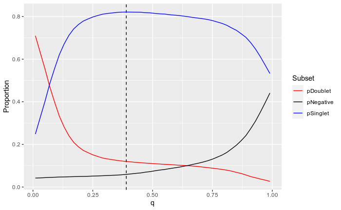

```r
## Identify ideal inter-maxima quantile to set barcode-specific thresholds
threshold.results.b2.1 <- findThresh(call.list=bar.table_sweep.list.b2)
ggplot(data=threshold.results.b2.1$res, aes(x=q, y=Proportion, color=Subset)) + geom_line() +
  geom_vline(xintercept=threshold.results.b2.1$extrema, lty=2) + scale_color_manual(values=c("red","black","blue"))
```

```r
# Finalize round 1 classifications, remove negative cells
b2.round1.calls <- classifyCells(bar.table.b2, q=findQ(threshold.results.b2.1$res, threshold.results.b2.1$extrema))
b2.neg.cells <- names(b2.round1.calls)[which(b2.round1.calls == "Negative")]
bar.table.b2 <- bar.table.b2[-which(rownames(bar.table.b2) %in% b2.neg.cells), ]
```

## Round 2 /B1 —————————————————————————————————–

```r
bar.table_sweep.list.b1 <- list()
n <- 0
for (q in seq(0.01, 0.99, by=0.02)) {
  print(q)
  n <- n + 1
  bar.table_sweep.list.b1[[n]] <- classifyCells(bar.table.b1, q=q)
  names(bar.table_sweep.list.b1)[n] <- paste("q=",q,sep="")
}
```

```
[1] 0.01
[1] 0.03
[1] 0.05
[1] 0.07
[1] 0.09
[1] 0.11
[1] 0.13
[1] 0.15
[1] 0.17
[1] 0.19
[1] 0.21
[1] 0.23
[1] 0.25
[1] 0.27
[1] 0.29
```

[output cut: 35 more lines]

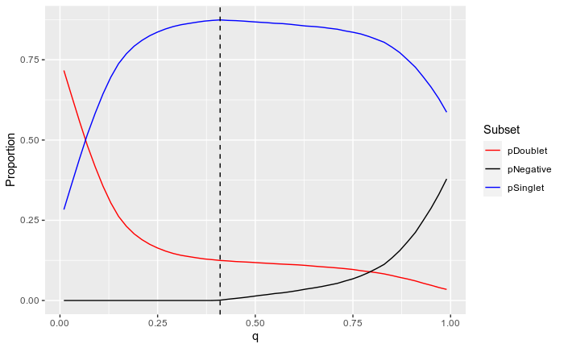

```r
threshold.results.b1.2 <- findThresh(call.list=bar.table_sweep.list.b1)
b1.round2.calls <- classifyCells(bar.table.b1, q=findQ(threshold.results.b1.2$res, threshold.results.b1.2$extrema))
b1.neg.cells <- c(b1.neg.cells, names(b1.round2.calls)[which(b1.round2.calls == "Negative")])

ggplot(data=threshold.results.b1.2$res, aes(x=q, y=Proportion, color=Subset)) + geom_line() +
  geom_vline(xintercept=threshold.results.b1.2$extrema, lty=2) + scale_color_manual(values=c("red","black","blue"))
```

## Round 2 /B2 —————————————————————————————————–

```r
bar.table_sweep.list.b2 <- list()
n <- 0
for (q in seq(0.01, 0.99, by=0.02)) {
  print(q)
  n <- n + 1
  bar.table_sweep.list.b2[[n]] <- classifyCells(bar.table.b2, q=q)
  names(bar.table_sweep.list.b2)[n] <- paste("q=",q,sep="")
}
```

```
[1] 0.01
[1] 0.03
[1] 0.05
[1] 0.07
[1] 0.09
[1] 0.11
[1] 0.13
[1] 0.15
[1] 0.17
[1] 0.19
[1] 0.21
[1] 0.23
[1] 0.25
[1] 0.27
[1] 0.29
```

[output cut: 35 more lines]

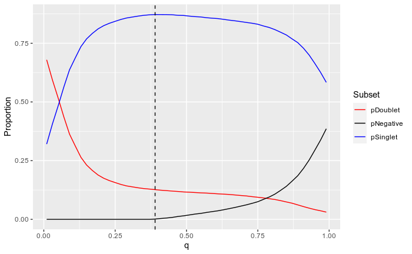

```r
threshold.results.b2.2 <- findThresh(call.list=bar.table_sweep.list.b2)
b2.round2.calls <- classifyCells(bar.table.b2, q=findQ(threshold.results.b2.2$res, threshold.results.b2.2$extrema))
b2.neg.cells <- c(b2.neg.cells, names(b2.round2.calls)[which(b2.round2.calls == "Negative")])

ggplot(data=threshold.results.b2.2$res, aes(x=q, y=Proportion, color=Subset)) + geom_line() +
  geom_vline(xintercept=threshold.results.b2.2$extrema, lty=2) + scale_color_manual(values=c("red","black","blue"))
```

## Repeat until all no negative cells remain (usually 3 rounds)…

## Round 3 /B1 —————————————————————————————————–

```r
bar.table_sweep.list.b1 <- list()
n <- 0
for (q in seq(0.01, 0.99, by=0.02)) {
  print(q)
  n <- n + 1
  bar.table_sweep.list.b1[[n]] <- classifyCells(bar.table.b1, q=q)
  names(bar.table_sweep.list.b1)[n] <- paste("q=",q,sep="")
}
```

```
[1] 0.01
[1] 0.03
[1] 0.05
[1] 0.07
[1] 0.09
[1] 0.11
[1] 0.13
[1] 0.15
[1] 0.17
[1] 0.19
[1] 0.21
[1] 0.23
[1] 0.25
[1] 0.27
[1] 0.29
```

[output cut: 35 more lines]

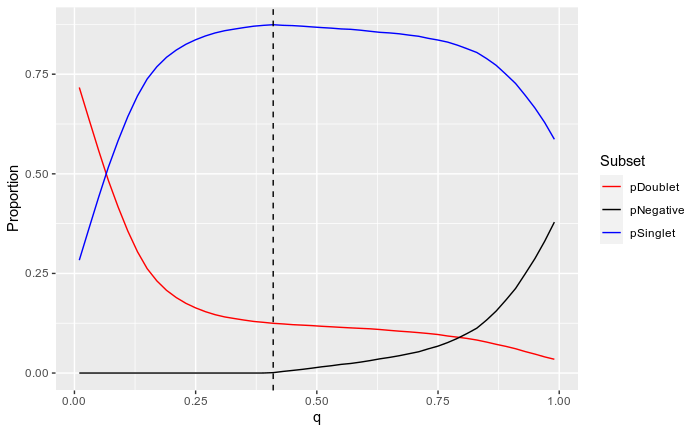

```r
threshold.results.b1.3 <- findThresh(call.list=bar.table_sweep.list.b1)
b1.round3.calls <- classifyCells(bar.table.b1, q=findQ(threshold.results.b1.3$res, threshold.results.b1.3$extrema))
b1.neg.cells <- c(b1.neg.cells, names(b1.round3.calls)[which(b1.round3.calls == "Negative")])

ggplot(data=threshold.results.b1.3$res, aes(x=q, y=Proportion, color=Subset)) + geom_line() +
  geom_vline(xintercept=threshold.results.b1.3$extrema, lty=2) + scale_color_manual(values=c("red","black","blue"))
```

```r
## Repeat until all no negative cells remain (usually 3 rounds)...
b1.final.calls <- c(b1.round3.calls, rep("Negative",length(neg.cells)))
```

```
Error: object 'neg.cells' not found
```

## Round 3 /B2 —————————————————————————————————–

```r
bar.table_sweep.list.b2 <- list()
n <- 0
for (q in seq(0.01, 0.99, by=0.02)) {
  print(q)
  n <- n + 1
  bar.table_sweep.list.b2[[n]] <- classifyCells(bar.table.b2, q=q)
  names(bar.table_sweep.list.b2)[n] <- paste("q=",q,sep="")
}
```

```
[1] 0.01
[1] 0.03
[1] 0.05
[1] 0.07
[1] 0.09
[1] 0.11
[1] 0.13
[1] 0.15
[1] 0.17
[1] 0.19
[1] 0.21
[1] 0.23
[1] 0.25
[1] 0.27
[1] 0.29
```

[output cut: 35 more lines]

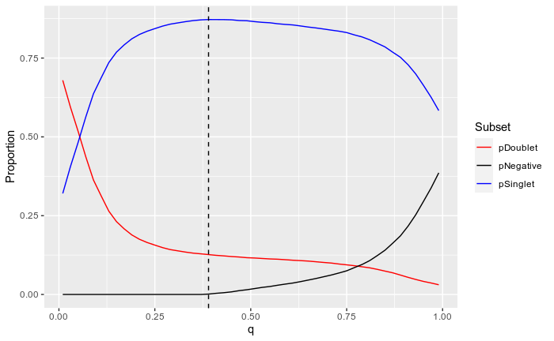

```r
threshold.results.b2.3 <- findThresh(call.list=bar.table_sweep.list.b2)
b2.round3.calls <- classifyCells(bar.table.b2, q=findQ(threshold.results.b2.3$res, threshold.results.b2.3$extrema))
b2.neg.cells <- c(b2.neg.cells, names(b2.round3.calls)[which(b2.round3.calls == "Negative")])

ggplot(data=threshold.results.b2.3$res, aes(x=q, y=Proportion, color=Subset)) + geom_line() +
  geom_vline(xintercept=threshold.results.b2.3$extrema, lty=2) + scale_color_manual(values=c("red","black","blue"))
```

```r
## Repeat until all no negative cells remain (usually 3 rounds)...
b2.final.calls <- c(b2.round3.calls, rep("Negative",length(b2.neg.cells)))
names(b2.final.calls) <- c(names(b2.round3.calls),b2.neg.cells)
save(b2.final.calls, file="b2.final.calls.Rdata")
```

```r
names(b2.final.calls) <- paste0("2_", names(b2.final.calls))
final.calls <- c(b1.final.calls, b2.final.calls)
```

```r
paste0("WC_sctransformed_demultiplexed_",Sys.Date(),".Rdata")
```

```
[1] "WC_sctransformed_demultiplexed_2020-05-01.Rdata"
```

[figure not shown]

```r
# how many cells are positive?
Idents(experiment.deMPx) <- "MULTI"
table(Idents(experiment.deMPx))
```

```
 Doublet     Bar3 Negative     Bar4     Bar2     Bar1
    4128     7264     2207     6895     7512     7019
```

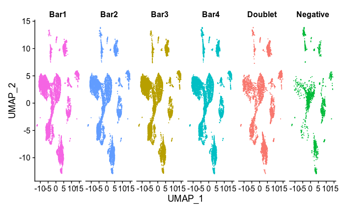

```r
DimPlot(experiment.deMPx, reduction = "umap", split.by = "MULTI", order = T) + theme(legend.position = "none")
```